# Análisis Integrado de Vulnerabilidades en la Industria Global del Agua Embotellada (2025/2026)

Dinámicas geopolíticas, crisis de suministros plásticos, regulación ambiental y transición hacia economía circular

Leo Caetana

Instituto de Ingeniería Industrial / Universidad Nacional de Cuyo

Bressan Joaquín

Instituto de Ingeniería Industrial / Universidad Nacional de Cuyo

Ludueña Alondra

Instituto de Ingeniería Industrial / Universidad Nacional de Cuyo

Manassero Franco

Instituto de Ingeniería Industrial / Universidad Nacional de Cuyo

Leslie García

Instituto de Ingeniería Industrial / Universidad Nacional de Cuyo

Don Ignacio

Instituto de Ingeniería Industrial / Universidad Nacional de Cuyo

2026-05-27

## Resumen

La industria global del agua embotellada atraviesa un período de transformación estructural impulsado por la convergencia de perturbaciones geopolíticas, la crisis de suministro de tereftalato de polietileno (PET), la regulación creciente sobre plásticos de un solo uso y el encarecimiento del transporte derivado del conflicto en el estrecho de Ormuz. El mercado global supera los 500.000 millones de litros anuales con un valor estimado de USD 280.000 millones y una tasa de crecimiento anual compuesto del 6,8%. En el contexto local, la República Argentina produce aproximadamente 3.850 millones de litros con un consumo per cápita de 85,4 litros por habitante por año. Este artículo examina las vulnerabilidades sistémicas de la cadena de valor, los vectores de riesgo operativo e identifica indicadores de sostenibilidad alineados con los criterios de producción más limpia de la ONUDI.

**Palabras clave:** agua embotellada; cadena de suministro; PET; economía circular; geopolítica hídrica; Argentina.

## 1. Introducción

El agua embotellada constituye uno de los segmentos de mayor dinamismo dentro de la industria global de bebidas no alcohólicas. Su crecimiento sostenido responde a la combinación de factores estructurales —urbanización, desconfianza en la calidad del agua de red en mercados emergentes y cambio en patrones de consumo— con tendencias coyunturales vinculadas a la disrupción de cadenas de suministro de insumos petroquímicos. La garantía de calidad química y microbiológica del producto final constituye un requisito regulatorio y comercial ineludible para los operadores del sector (Fernandez Rivera, 2023), en tanto que el diseño de modelos de negocio viables para nuevas plantas embotelladoras sigue siendo un desafío estratégico en mercados emergentes (Valarezo León & Tibillín Peñaloza, 2025).

La campaña 2025/2026 se caracteriza por la acumulación simultánea de presiones externas que afectan tanto el lado de los costos de producción como la disponibilidad de materias primas estratégicas. La escalada en el precio del crudo derivada de las tensiones en el estrecho de Ormuz, la escasez certificada de PET reciclado (*food-grade*) y la inestabilidad en cuencas hídricas andinas configuran un escenario de riesgo multidimensional para los operadores de la industria.

## 2. Mercado Global: Estructura y Actores Principales

### 2.1 Balance de oferta y demanda

El mercado global de agua embotellada registra en el período analizado un volumen de producción superior a los 500.000 millones de litros, con una demanda sostenida que refleja la consolidación del producto como bien de consumo masivo en economías emergentes y su reposicionamiento como producto premium en mercados desarrollados.

La segmentación del mercado por tipo de producto muestra que el agua purificada concentra el 42% del volumen total, seguida por el agua mineral natural (38%), el agua gasificada (12%) y las aguas saborizadas o funcionales (8%), categoría de crecimiento más acelerado en el período reciente.

### 2.2 Principales actores y cuotas de mercado

Tabla 1. Principales empresas embotelladoras de agua a nivel global: cuota de mercado estimada y volumen de producción para el período 2025/2026. Fuente: elaboración propia basada en Beverage Marketing Corporation (2025) y Grand View Research (2025).

| Empresa | Cuota de Mercado (%) | Volumen Est. (mill. L) | Segmento Principal |
| --- | --- | --- | --- |
| Nestlé (Pure Life, Perrier, S. Pellegrino) | 21 | 105000 | Premium / Natural |
| Danone (Evian, Volvic) | 14 | 70000 | Mineral Natural |
| Coca-Cola (Dasani, SmartWater) | 12 | 60000 | Purificada |
| PepsiCo (Aquafina, LIFEWTR) | 10 | 50000 | Purificada |
| Otras marcas regionales | 43 | 215000 | Mixto |

La Tabla 1 evidencia que las cuatro empresas transnacionales líderes controlan colectivamente el 57% del volumen global, mientras que el 43% restante se distribuye entre cientos de operadores regionales y locales. Esta estructura oligopólica moderada coexiste con una elevada heterogeneidad en los segmentos de valor. La rentabilidad financiera de los operadores de menor escala depende en gran medida de la correcta gestión del capital de trabajo y de la toma de decisiones basada en información contable actualizada (Mendoza de la Cruz & Lucio Pillasagua, 2023).

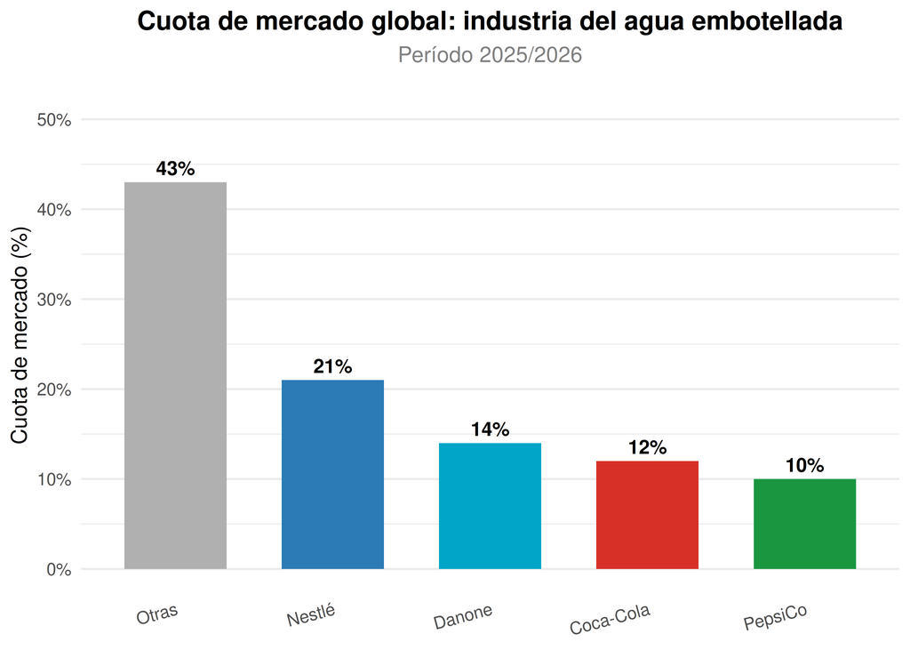

Figura 1. Distribución de la cuota de mercado global en la industria del agua embotellada (2025/2026). Fuente: elaboración propia basada en Beverage Marketing Corporation (2025) y Zenith International (2026).

## 3. Perturbaciones Geopolíticas y Disrupciones de Cadena de Suministro

### 3.1 Impacto del conflicto en el estrecho de Ormuz sobre los costos de producción

La Figura 2 ilustra la correlación entre la evolución del precio internacional del PET virgen y el precio promedio de venta al consumidor del agua embotellada estándar entre 2022 y 2026.

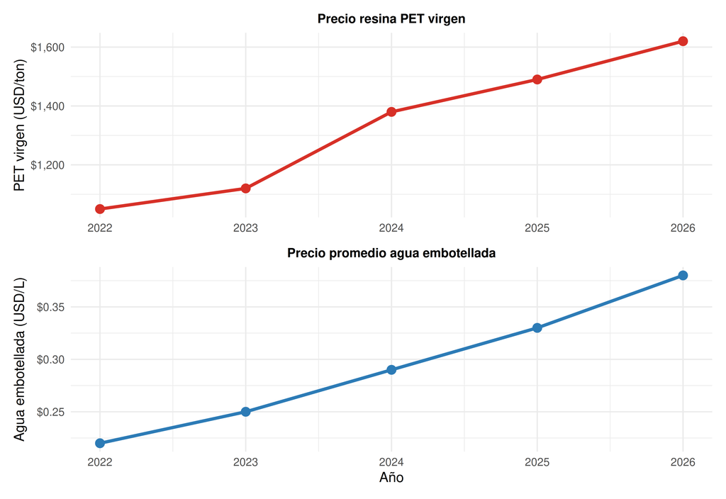

Figura 2. Evolución del precio internacional de la resina PET virgen (USD/tonelada) y precio promedio de venta al consumidor del agua embotellada estándar (USD/litro) entre 2022 y 2026. Fuente: elaboración propia basada en ICIS Chemical Business (2026) y Nielsen IQ (2026).

### 3.2 Crisis de suministro de rPET *food-grade*

La escasez de PET reciclado certificado para contacto alimentario (*rPET food-grade*) constituye uno de los cuellos de botella más críticos del período analizado. La Directiva Europea de Plásticos de Un Solo Uso (SUP) y los objetivos de la legislación estadounidense sobre contenido reciclado han generado una demanda simultánea de rPET que supera la capacidad instalada de los sistemas de recolección y reciclado.

El costo de adquisición de rPET food-grade certificado ha aumentado un 31,2% respecto al período precedente, con retrasos promedio de 21 días en las entregas de preformas por parte de proveedores asiáticos de segunda fila. En paralelo, la industria explora el desarrollo de envases con tecnologías de barrera activa y materiales de nueva generación como respuesta estructural a la volatilidad en el suministro de resinas convencionales (Velasco Guerra, 2026).

### 3.3 Cuantificación del impacto de perturbaciones externas

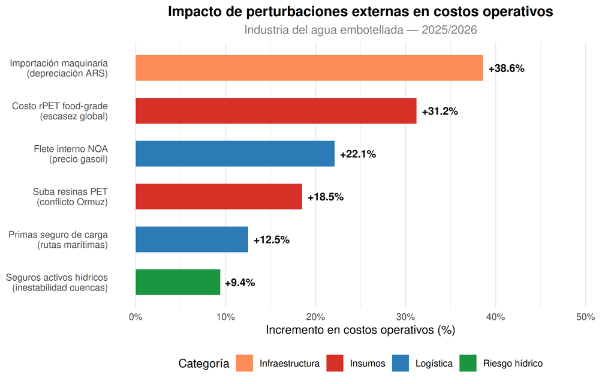

Figura 5. Impacto porcentual estimado de las principales perturbaciones externas sobre los costos operativos de la industria del agua embotellada durante 2025/2026. Fuente: elaboración propia basada en ICIS (2026), Wood Mackenzie (2026) y análisis sectorial propio.

## 4. Dimensión Local: La Industria Argentina del Agua Embotellada

### 4.1 Estructura productiva

La industria argentina del agua embotellada cuenta con aproximadamente 85 plantas activas distribuidas en todo el territorio nacional. La región Pampeana y el Gran Buenos Aires concentran el 48% de la producción total, seguida por la región de Cuyo (Mendoza y San Juan, 22%), el Noroeste Argentino (14%), la Patagonia (10%) y el resto del país (6%). La dimensión social de estas plantas resulta crecientemente relevante: la responsabilidad social empresarial emerge como un factor diferenciador en la relación entre embotelladoras y comunidades locales, especialmente en regiones donde la presión sobre los recursos hídricos genera tensiones con otros actores del territorio (Orrala Suárez, 2023).

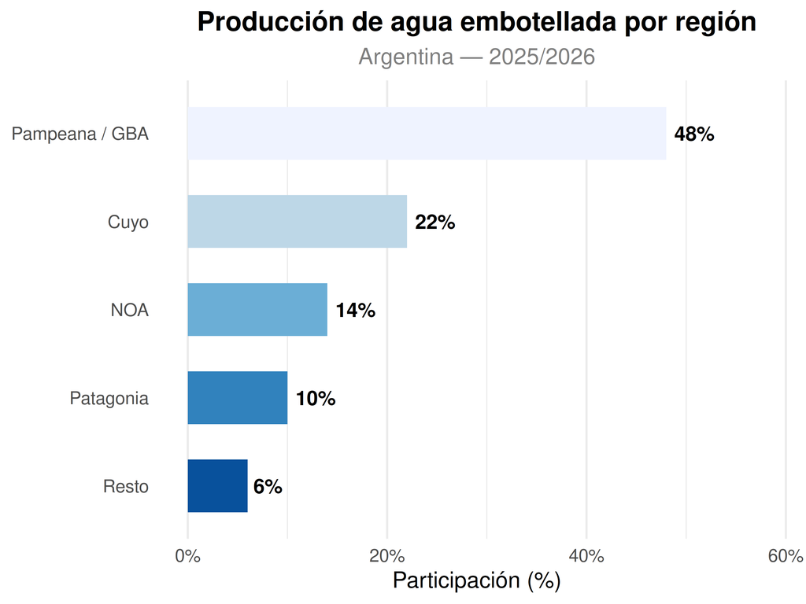

Figura 3. Distribución porcentual de la producción de agua embotellada en Argentina según región geográfica para el período 2025/2026. NOA: Noroeste Argentino. Fuente: elaboración propia basada en CADAM (2025) y datos del Ministerio de Producción de la Nación Argentina (2026).

### 4.2 Indicadores operativos del período 2025/2026

La Tabla 2 sintetiza los principales indicadores operativos de la industria argentina del agua embotellada para el período analizado. La mejora de estos indicadores requiere intervenciones sistemáticas: los estudios de tiempos en líneas de embotellado permiten identificar cuellos de botella y reducir tiempos muertos (Bejarano et al., 2024), mientras que la aplicación de la metodología DMAIC posibilita reducciones significativas en los costos de producción mediante el control estadístico de variables críticas del proceso (Vargas-Díaz et al., 2025).

Tabla 2. Indicadores operativos clave de la industria del agua embotellada en Argentina durante el período 2025/2026. HoReCa: Hoteles, Restaurantes y Cafeterías.

| Indicador | Valor | Fuente |
| --- | --- | --- |
| **Producción y consumo** |  |  |
| Volumen total producido | 3.850 millones de litros | CADAM (2025) |
| Consumo per cápita | 85,4 L/habitante/año | Euromonitor International (2026) |
| **Valor y distribución** |  |  |
| Valor de mercado interno | USD 1.240 millones | Nielsen IQ (2026) |
| Participación canal supermercados | 52,0% | Nielsen IQ (2026) |
| Participación canal almacenes/kioscos | 31,0% | Nielsen IQ (2026) |
| Participación canal HoReCa | 17,0% | Nielsen IQ (2026) |
| **Eficiencia operativa** |  |  |
| Agua perdida en proceso | 2,8 L por L embotellado | Elaboración propia |
| Tasa de rechazo de botellas defectuosas | 1,4% | Elaboración propia |
| Costo económico por ineficiencia | USD 18,7 millones | Elaboración propia |
| **Desempeño exportador** |  |  |
| Volumen exportado | 42,5 millones de litros | INDEC (2026) |
| Ingresos FOB por exportaciones | USD 31,8 millones | INDEC (2026) |
| Crecimiento interanual exportaciones | +12,3% | INDEC (2026) |

### 4.3 Dinámica del consumo per cápita (2018–2027)

[figure not shown]

Figura 4. Tendencia del consumo per cápita de agua embotellada en la República Argentina entre 2018 y 2026, con proyección lineal para 2027 (línea punteada). Fuente: elaboración propia basada en Euromonitor International (2026) y CADAM (2025).

### 4.4 Vulnerabilidades estratégicas locales

La depreciación sostenida del peso argentino incrementa el costo de importación de maquinaria de soplado de alta eficiencia —fabricada principalmente en Alemania e Italia— en un 38,6%, postergando el reemplazo de líneas obsoletas con alto consumo energético. Esta postergación hace más crítica la implementación de planes de mantenimiento preventivo sobre el equipamiento existente, cuya ausencia genera paradas no programadas con impacto directo en la productividad y en los costos fijos unitarios (Mendoza Mejía, 2024). Adicionalmente, el encarecimiento del gasoil derivado del conflicto en Ormuz eleva los costos de flete interno desde el NOA hacia los centros de distribución en el Gran Buenos Aires en un 22,1%, erosionando el margen neto de exportación.

## 5. Indicadores de Sostenibilidad y Producción más Limpia

En consonancia con los criterios de la Organización de las Naciones Unidas para el Desarrollo Industrial (ONUDI) y el enfoque de *Cleaner Production*, se proponen los siguientes indicadores para la evaluación de la sostenibilidad del sector:

1. **Huella hídrica** (*water footprint*) por litro de agua embotellada producida bajo diferentes esquemas de captación (superficial versus acuífero profundo), conforme a la norma ISO 14046.
2. **Análisis de ciclo de vida** (LCA) comparativo entre botella PET virgen, botella con 25% de rPET y envase de vidrio retornable, ante escenarios de volatilidad en el precio de resinas petroquímicas.
3. **Resiliencia de la cadena de suministro** de rPET *food-grade* ante la crisis de disponibilidad derivada de la Directiva SUP de la UE.
4. **Índice de eficiencia hídrica industrial** (IEH): litros de agua de proceso consumidos por litro de producto final comercializable. El valor actual de 2,8 L/L indica un margen significativo de mejora. La implementación de metodologías de organización del puesto de trabajo como las 5S ha demostrado incrementos de productividad y reducción de desperdicios en plantas embotelladoras de escala similar (Chilón Aguilar et al., 2017); en la misma línea, la aplicación de principios Lean Manufacturing permite optimizar los flujos de producción y reducir las pérdidas de agua en proceso (Tomalá Orrala, 2023).
5. **Tasa de recuperación post-consumo** de envases PET como *proxy* de circularidad sectorial. El valor actual del 31,0% en Argentina contrasta con los niveles superiores al 50% registrados en economías de la OCDE.

## 6. Conclusiones

La industria global del agua embotellada exhibe en el período 2025/2026 una convergencia inédita de presiones sobre su estructura de costos, disponibilidad de insumos estratégicos y legitimidad regulatoria. Las empresas con mayor exposición a insumos petroquímicos importados y con menor avance en la incorporación de rPET presentan los perfiles de vulnerabilidad más elevados.

En el contexto argentino, la combinación de depreciación cambiaria, encarecimiento del gasoil y restricciones en cuencas hídricas andinas configura un escenario que demanda una revisión profunda del modelo operativo vigente. La transición hacia esquemas de economía circular —con metas progresivas de incorporación de rPET, mejora de la eficiencia hídrica industrial y trazabilidad del origen— se presenta como la respuesta estratégica más robusta frente a la incertidumbre estructural del período.

## Referencias

Bejarano, C., Sánchez, K., Domínguez, A., & Moreira, C. (2024). Estudio de tiempos en una empresa embotelladora de agua. *Polo Del Conocimiento*, *9*(6), 2405–2413. https://doi.org/10.23857/pc.v9i6.4188

Chilón Aguilar, X. M., Esquivel Paredes, L., & Estela Tamay, W. (2017). Implementación de las 5S para incrementar la productividad en una planta embotelladora de agua. *INGnosis*, *3*(1), 130–139. https://doi.org/10.26820/ingnosis.2017.01.010

Fernandez Rivera, J. (2023). *Evaluación de la calidad química y microbiológica del agua embotellada en las plantas purificadoras de la ciudad de tetela de ocampo, puebla* [Tesis de licenciatura]. Benemérita Universidad Autónoma de Puebla.

Mendoza de la Cruz, W. J., & Lucio Pillasagua, A. (2023). *Rentabilidad financiera y toma de decisiones en la embotelladora de agua cántaro water* [Tesis de grado]. Universidad Técnica de Ambato.

Mendoza Mejía, J. J. (2024). *Diseño de la investigación de un plan de mantenimiento preventivo para la máquina LavaClassic plus D5 de una empresa embotelladora en zacapa* [Tesis de grado]. Universidad de San Carlos de Guatemala.

Orrala Suárez, A. N. (2023). *Responsabilidad social empresarial en las empresas embotelladoras de agua, cantón salinas, provincia de santa elena, año 2022* [Tesis de grado]. Universidad Estatal Península de Santa Elena.

Tomalá Orrala, B. A. (2023). *Aplicación lean manufacturing para la optimización del sistema de producción en la planta purificadora y embotelladora de agua aquafit s.a, santa elena* [Tesis de grado]. Universidad Estatal Península de Santa Elena.

Valarezo León, D. I., & Tibillín Peñaloza, A. D. (2025). *Modelo de negocio para la creación de una empresa embotelladora de agua purificada en la parroquia molleturo periodo 2024–2025* [Trabajo de titulación]. Universidad de Cuenca.

Vargas-Díaz, J. G., León-Reyes, R. J., González-Vásquez, J. A., & Ulloa-Bocanegra, S. G. (2025). Implementación de la metodología DMAIC para reducir costos de producción en una embotelladora de agua, trujillo 2025. *Revista de Investigación En Ingeniería Industrial*, *14*(1), 45–58.

Velasco Guerra, N. R. (2026). Análisis de los retos de las nuevas tecnologías en envases tecnológicos para una embotelladora de agua. *ÉLITE: Revista de Investigación En Ciencias Administrativas y Tecnología*, *8*(1), 112–128. https://doi.org/10.5281/zenodo.14773487